# Rain-on-Snow Distributional Learning Model

This document explores a distributional learning model for prediction of gridded runoff from precipitation and snowmelt inputs for a region over the Alps.

## Setup

Load the packages used throughout the analysis and define a simple colour palette for the maps.

```r
library(tidyverse)
library(probaverse)
library(terra)
library(tidyterra)
devtools::load_all()
```

```
ℹ Loading rainonsnow
```

```r
# "Vibrant Summer" palette
# https://coolors.co/palette/ff595e-ffca3a-8ac926-1982c4-6a4c93
pal <- rev(c("#ff595e", "#ffca3a", "#8ac926", "#1982c4", "#6a4c93"))
```

## Load Data

Read the ERA5-Land NetCDF file and inspect its basic spatial dimensions. This dataset was retrieved by the Python script `download_data.py`:

- Data are hourly from 1992-10-05 to 1993-03-31 – one “winter” period just for exposition purposes. The question of “what data should we look at” will come later (albeit soon).
- The study area is between latitudes 43.0 and 48.5 and longitudes 5.0 and 16.5 – a box that roughly covers the European Alps.
- Data are from ERA5-Land. Snow data from ESA has been difficult to obtain; will try again later.

```r
ds <- rast(here::here("data", "era5_land_hourly_alps.nc"))
```

```r
res(ds)
```

```
[1] 1 1
```

```r
ncell(ds)
```

```
[1] 72
```

Convert the raster object to a tabular format for tabular workflow, and lengthen by time.

```r
dat <- as_tibble(ds, xy = TRUE) |>
  pivot_longer(
    !c(x, y),
    names_to = c(".value", "hour"),
    names_pattern = "^(.+)_([0-9]+)$"
  ) |>
  mutate(hour = as.numeric(hour))
```

Deal with the “almost zero” cases.

```r
dat <- mutate(
  dat,
  total_precipitation_hourly = if_else(
    total_precipitation_hourly < 1e-7,
    0,
    total_precipitation_hourly
  ),
  snowmelt_hourly = if_else(
    snowmelt_hourly < 1e-7,
    0,
    snowmelt_hourly
  )
)
```

A nice tabular dataset is now ready for analysis:

```r
dat
```

```
# A tibble: 305,856 × 12
       x     y  hour temperature_2m total_precipitation_hourly snowfall_hourly
   <dbl> <dbl> <dbl>          <dbl>                      <dbl>           <dbl>
 1  43.5  16.5     1           285.                0.00000437                0
 2  43.5  16.5     2           285.                0.00000543                0
 3  43.5  16.5     3           284.                0.00000180                0
 4  43.5  16.5     4           284.                0.000000292               0
 5  43.5  16.5     5           284.                0                         0
 6  43.5  16.5     6           284.                0                         0
 7  43.5  16.5     7           285.                0                         0
 8  43.5  16.5     8           285.                0.000000542               0
 9  43.5  16.5     9           286.                0.00000969                0
10  43.5  16.5    10           287.                0.0000572                 0
# ℹ 305,846 more rows
# ℹ 6 more variables: snowmelt_hourly <dbl>, snow_depth <dbl>,
#   snow_depth_water_equivalent <dbl>, runoff_hourly <dbl>,
#   surface_runoff_hourly <dbl>, sub_surface_runoff_hourly <dbl>
```

## Exploratory Plots

These plots provide a quick look at the spatial pattern of runoff and its relation to rainfall and snowmelt. The basemap is omitted for now.

Spatial runoff at 2 pm on October 5:

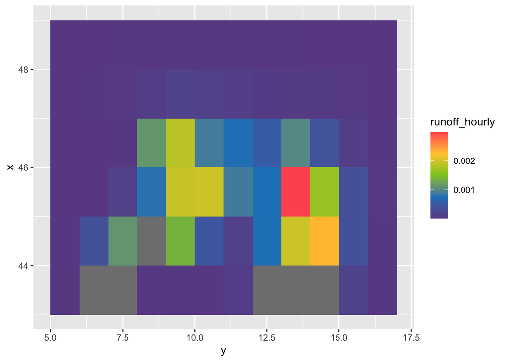

```r
dat |>
  filter(hour == 14) |>
  ggplot(aes(y, x)) +
  geom_tile(aes(fill = runoff_hourly)) +
  scale_fill_gradientn(colours = pal)
```

Runoff time series by cell (upper-left corner):

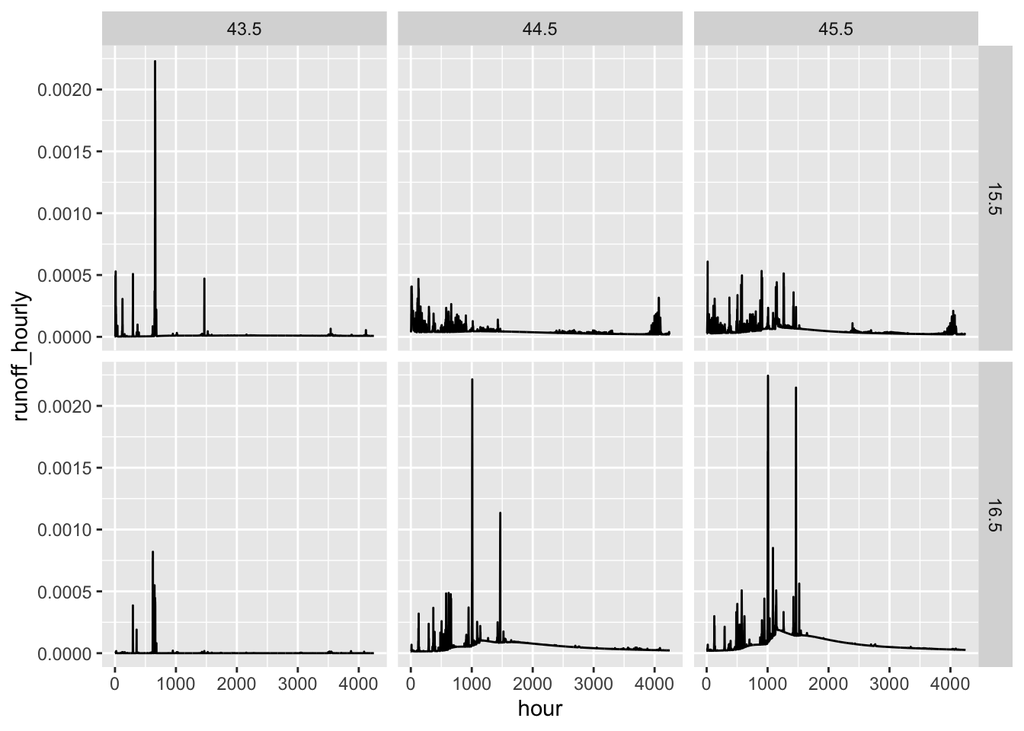

```r
dat |>
  filter(x < 46, y > 15) |>
  ggplot(aes(hour, runoff_hourly)) +
  facet_grid(y ~ x) +
  geom_line()
```

Runoff vs snowmelt by cell (upper-left corner):

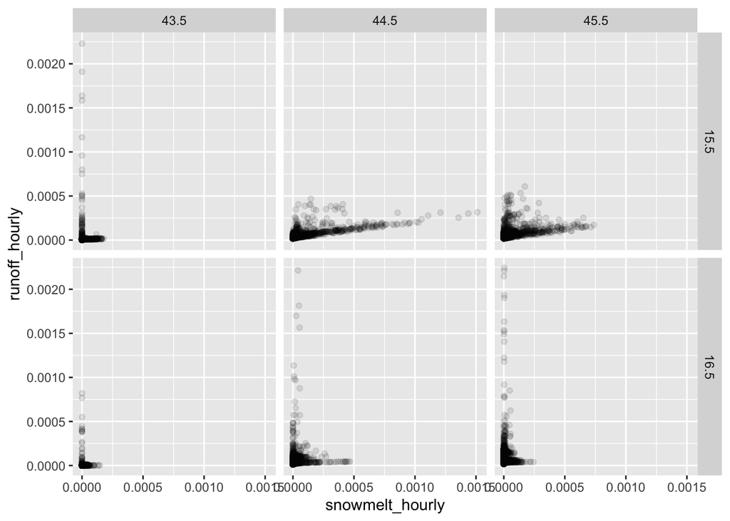

```r
dat |>
  filter(x < 46, y > 15) |>
  ggplot(aes(snowmelt_hourly, runoff_hourly)) +
  facet_grid(y ~ x) +
  geom_point(alpha = 0.1)
```

Runoff vs precipitation by cell (upper-left corner). We’re only using precipitation right now for exposition purposes; rainfall is harder to get and is a task for another day.

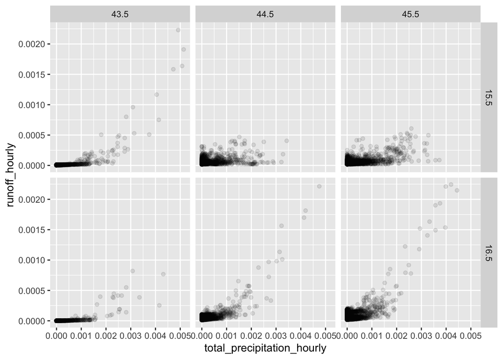

```r
dat |>
  filter(x < 46, y > 15) |>
  ggplot(aes(total_precipitation_hourly, runoff_hourly)) +
  facet_grid(y ~ x) +
  geom_point(alpha = 0.1)
```

## Distributional Learning Model

Fit a distributional random forest model separately at each grid cell.

This method follows quantile regression forests (Meinshausen 2006). Instead of calculating only the mean at each leaf in the random forest, conditional quantiles are estimated; taken together, these give the full conditional distribution.

Distributional learning wrappers can be found under `R/` in this repository. These are needed because the base methods (e.g., `quantregForest::quantregForest()`) are geared towards quantiles, not distributions. The [probaverse](https://probaverse.com) is used for the handling of distributions.

```r
models <- dat |>
  nest(data = !c(x, y)) |>
  mutate(dl_rqforest = map(
    data,
    dl_rqforest,
    yname = "runoff_hourly",
    xnames = c("total_precipitation_hourly", "snowmelt_hourly")
  ))

# Inspect
models
```

```
# A tibble: 72 × 4
       x     y data                  dl_rqforest
   <dbl> <dbl> <list>                <list>
 1  43.5  16.5 <tibble [4,248 × 10]> <dl_rqfrs>
 2  44.5  16.5 <tibble [4,248 × 10]> <dl_rqfrs>
 3  45.5  16.5 <tibble [4,248 × 10]> <dl_rqfrs>
 4  46.5  16.5 <tibble [4,248 × 10]> <dl_rqfrs>
 5  47.5  16.5 <tibble [4,248 × 10]> <dl_rqfrs>
 6  48.5  16.5 <tibble [4,248 × 10]> <dl_rqfrs>
 7  43.5  15.5 <tibble [4,248 × 10]> <dl_rqfrs>
 8  44.5  15.5 <tibble [4,248 × 10]> <dl_rqfrs>
 9  45.5  15.5 <tibble [4,248 × 10]> <dl_rqfrs>
10  46.5  15.5 <tibble [4,248 × 10]> <dl_rqfrs>
# ℹ 62 more rows
```

## Predictions on Training Data

Generate predictive distributions for each hour on record. At this stage, we are not concerning ourselves with a holdout set, since this work is for expository purposes at this time.

```r
pred <- models |>
  mutate(hat = map2(dl_rqforest, data, predict)) |>
  select(!dl_rqforest) |>
  unnest(c(data, hat))

# Inspect
pred
```

```
# A tibble: 305,856 × 13
       x     y  hour temperature_2m total_precipitation_hourly snowfall_hourly
   <dbl> <dbl> <dbl>          <dbl>                      <dbl>           <dbl>
 1  43.5  16.5     1           285.                0.00000437                0
 2  43.5  16.5     2           285.                0.00000543                0
 3  43.5  16.5     3           284.                0.00000180                0
 4  43.5  16.5     4           284.                0.000000292               0
 5  43.5  16.5     5           284.                0                         0
 6  43.5  16.5     6           284.                0                         0
 7  43.5  16.5     7           285.                0                         0
 8  43.5  16.5     8           285.                0.000000542               0
 9  43.5  16.5     9           286.                0.00000969                0
10  43.5  16.5    10           287.                0.0000572                 0
# ℹ 305,846 more rows
# ℹ 7 more variables: snowmelt_hourly <dbl>, snow_depth <dbl>,
#   snow_depth_water_equivalent <dbl>, runoff_hourly <dbl>,
#   surface_runoff_hourly <dbl>, sub_surface_runoff_hourly <dbl>, hat <list>
```

Inspect one fitted predictive distribution directly; here’s its CDF, for example:

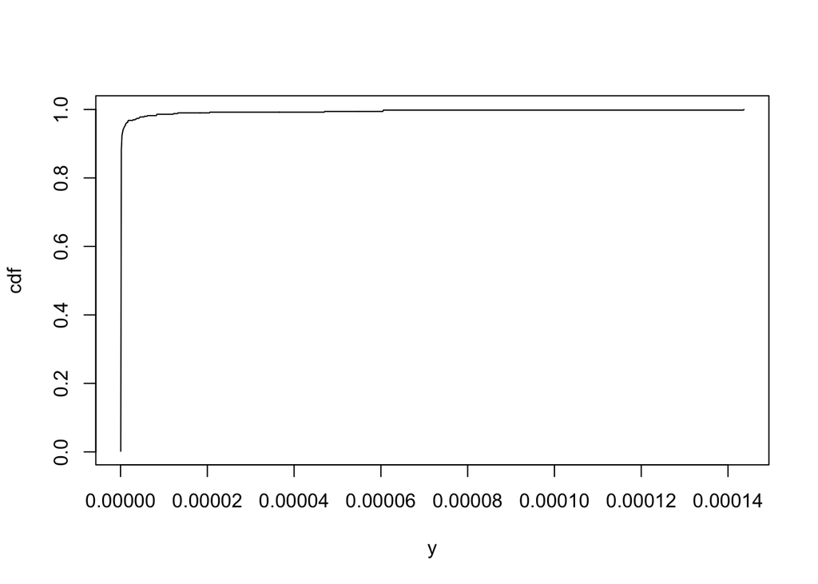

```r
example_prediction <- pred$hat[[1]]
plot(example_prediction, n = 1000)
```

Note that the method employed by Bevacqua et al. (Bevacqua et al. 2017) forces this distribution to be normal.

Here are its quartiles:

```r
enframe_quantile(example_prediction, at = c(0.25, 0.5, 0.75))
```

```
# A tibble: 3 × 2
   .arg     quantile
  <dbl>        <dbl>
1  0.25 0.0000000784
2  0.5  0.000000114
3  0.75 0.000000131
```

Its mean:

```r
mean(example_prediction)
```

```
[1] 9.464235e-07
```

## P-P Plot

For distributional learning methods, a P-P plot is a way to assess calibration (Coia 2017). In other words, could the data have feasibly been drawn from the predictive distributions? The closer the points are to the 1:1 line, the better calibrated the model is. Anything “off” from this line indicates a tendency for our predictive distributions to, for example, perhaps be too large, too small, or too wide. However, this isn’t the full picture, because it doesn’t reward narrowness of the distribution: for instance, the marginal distribution would appear perfectly calibrated, but for a predictive model, is too wide.

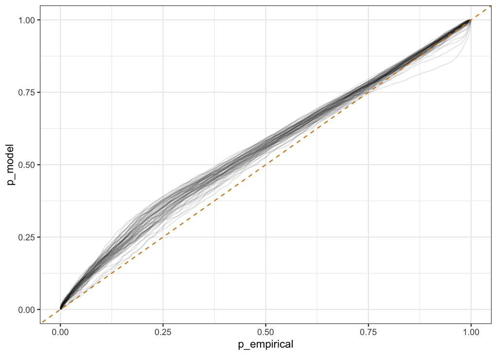

```r
pp_data <- pred |>
  group_by(x, y) |>
  mutate(
    p_model = map2_dbl(hat, runoff_hourly, eval_cdf),
    p_empirical = uscore(p_model)
  ) |>
  select(x, y, starts_with("p_"))

ggplot(pp_data, aes(p_empirical, p_model)) +
  geom_line(aes(group = interaction(x, y)), alpha = 0.1) +
  geom_abline(intercept = 0, slope = 1, linetype = "dashed", colour = "orange3") +
  theme_bw()
```

To include both calibration and narrowness of predictions, the quantile score is a useful measure (Gneiting 2011). Get quantiles and quantile scores from probaverse.

```r
qscores_model <- pred |>
  mutate(
    df = map(
      hat,
      enframe_quantile,
      at = 1:99 / 100,
      arg_name = "tau"
    )
  ) |>
  unnest(df) |>
  group_by(x, y, tau) |>
  summarise(
    qscore_model = mean(quantile_score(runoff_hourly, xhat = quantile, tau = tau)),
    .groups = "drop"
  )

# Inspect
qscores_model
```

```
# A tibble: 7,128 × 4
       x     y   tau qscore_model
   <dbl> <dbl> <dbl>        <dbl>
 1  43.5   5.5  0.01  0.000000454
 2  43.5   5.5  0.02  0.000000879
 3  43.5   5.5  0.03  0.00000129
 4  43.5   5.5  0.04  0.00000170
 5  43.5   5.5  0.05  0.00000207
 6  43.5   5.5  0.06  0.00000240
 7  43.5   5.5  0.07  0.00000273
 8  43.5   5.5  0.08  0.00000306
 9  43.5   5.5  0.09  0.00000334
10  43.5   5.5  0.1   0.00000361
# ℹ 7,118 more rows
```

On their own, quantile scores do not hold an obvious interpretation. They are better when compared against the models obtained from the univariate method – that is, always predicting the marginal distribution obtained from the univariate data. This is just like the calculation of $R^2$, except instead of looking at the reduction of variance, it’s the reduction in quantile score. Call this the “skill score”.

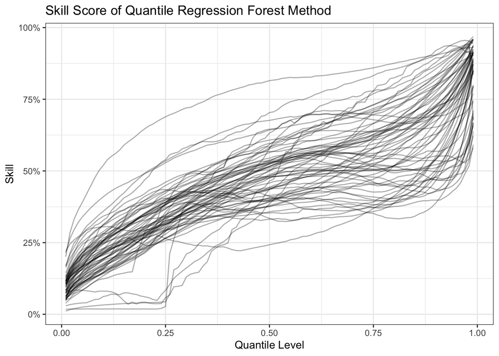

```r
null_model <- dat |>
  group_by(x, y) |>
  summarise(runoff_hourly = list(runoff_hourly), .groups = "drop") |>
  mutate(marginal = map(runoff_hourly, dst_empirical))

null_quantiles <- null_model |>
  mutate(
    df = map(marginal, enframe_quantile, at = 1:99 / 100, arg_name = "tau")
  ) |>
  select(!marginal) |>
  unnest(df)

qscores_null <- null_quantiles |>
  mutate(
    qscore_null = pmap_dbl(
      list(runoff_hourly, quantile, tau),
      \(y, q, p) mean(quantile_score(y, xhat = q, tau = p))
    )
  ) |>
  select(x, y, tau, qscore_null)

qscores <- left_join(qscores_null, qscores_model, by = c("x", "y", "tau")) |>
  mutate(skill_score = 1 - qscore_model / qscore_null)

ggplot(qscores, aes(tau, skill_score)) +
  geom_line(
    aes(group = interaction(x, y)),
    alpha = 0.33
  ) +
  labs(
    x = "Quantile Level",
    title = "Skill Score of Quantile Regression Forest Method"
  ) +
  scale_y_continuous("Skill", labels = scales::percent_format()) +
  theme_bw()
```

## Marginal Distributions

Unconditional runoff distributions are useful for calculating extreme events like the 100-year or 200-year runoff event. The dataset will have to be changed in order to calculate these events, but the process can be demonstrated with these models nonetheless, by [mixing](https://en.wikipedia.org/wiki/Mixture_distribution) all the predictive distributions in each cell. This calculates the marginal distribution of runoff, unconditional on the model inputs. Calculations are made easy by the probaverse: just use distplyr’s `mix()` function.

```r
marginals <- pred |>
  group_by(x, y) |>
  summarise(marginal_runoff = list(mix(hat)), .groups = "drop")
```

Here is an example unconditional distribution (CDF) for one of the cells in the study region.

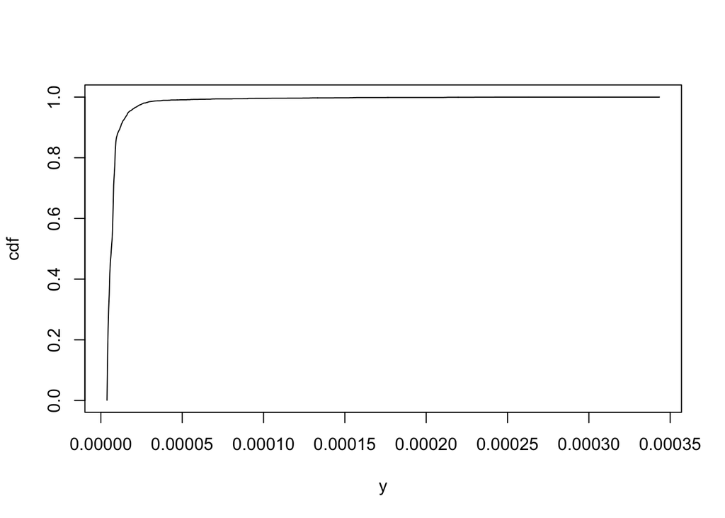

```r
plot(marginals$marginal_runoff[[4]], n = 1000)
```

One objective will be to show that, particularly when parametric tails are fit via distributional learning, this estimate of the marginal distribution will surpass that of the univariate method. I’ve seen this in small simulations before, and for a binary view of rain and snowmelt processes ([BGC, 2025](https://www.fraserbasin.bc.ca/_Library/TR_Flood/Coldwater%20and%20Nicola%20Rivers%20FFA%20Final%20Report.pdf)), and suspect it’s because the shape of the distribution’s tail can be explained by the drivers, rather than simply trying to extrapolate the tail from a univariate view. In practical terms: an extreme runoff becomes expected in the face of a large rainfall and large snowmelt, rather than something that appears to have come from “out of the blue”.

## Percentiles Maps

Getting the unconditional distributions is useful for making a map of, say, the 100-year flood (with the appropriate dataset). For now, instead, take a look at the 1% and 99% values.

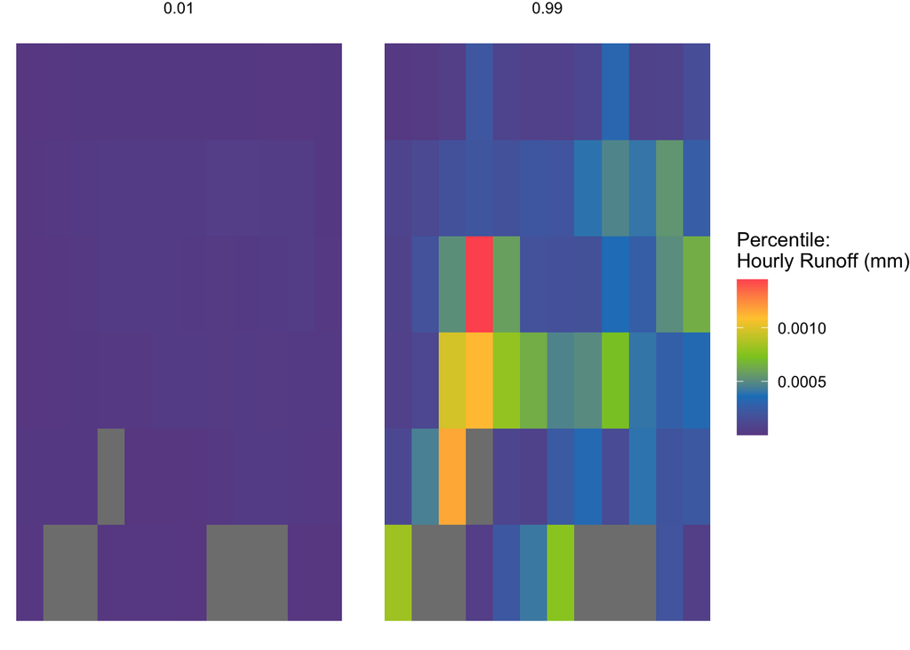

```r
pctl <- marginals |>
  mutate(
    df = map(
      marginal_runoff,
      enframe_quantile,
      at = c(0.01, 0.99),
      arg_name = "tau"
    )
  ) |>
  select(!marginal_runoff) |>
  unnest(df)

ggplot(pctl, aes(y, x)) +
  facet_wrap(~ tau, ncol = 2) +
  geom_tile(aes(fill = quantile)) +
  theme_void() +
  scale_fill_gradientn("Percentile:\nHourly Runoff (mm)", colours = pal)
```

From a more day-to-day prediction standpoint, we can look at the percentiles of the predictive distributions (i.e., the conditional ones), and compare to what was observed. Do this for 2 pm on October 5; also compare with the mean predicted runoff (i.e., classical machine learning).

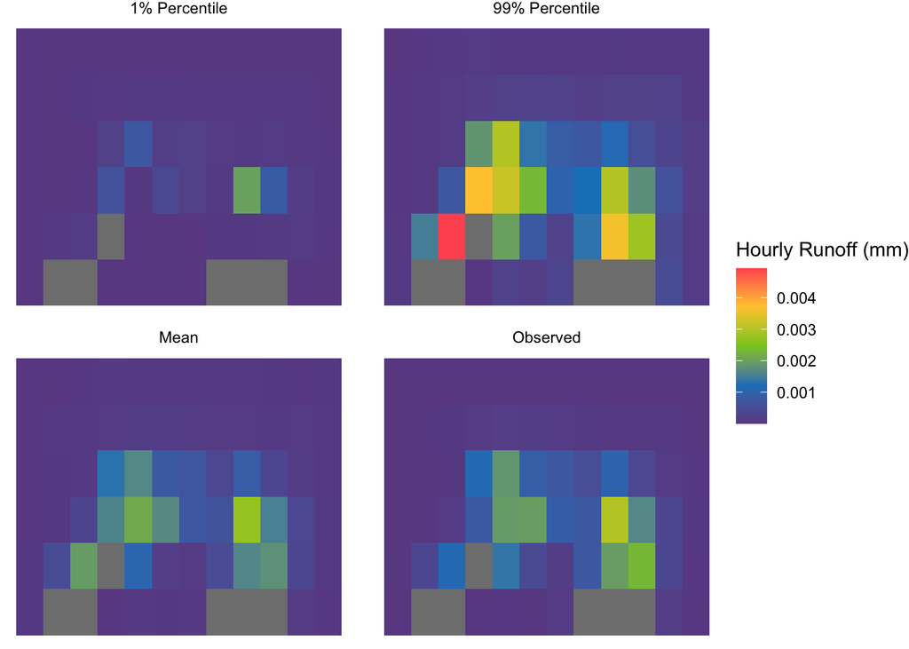

```r
pctl_hr14 <- pred |>
  filter(hour == 14) |>
  mutate(
    runoff_01 = map_dbl(hat, eval_quantile, at = 0.01),
    runoff_99 = map_dbl(hat, eval_quantile, at = 0.99),
    runoff_mean = map_dbl(hat, mean),
  ) |>
  select(x, y, starts_with("runoff")) |>
  pivot_longer(
    starts_with("runoff"),
    names_to = c(".value", "quantity"),
    names_sep = "_"
  ) |>
  mutate(quantity = case_when(
    quantity == "01" ~ "1% Percentile",
    quantity == "99" ~ "99% Percentile",
    quantity == "mean" ~ "Mean",
    TRUE ~ "Observed"
  ))

ggplot(pctl_hr14, aes(y, x)) +
  facet_wrap(~ quantity, nrow = 2) +
  geom_tile(aes(fill = runoff)) +
  theme_void() +
  scale_fill_gradientn("Hourly Runoff (mm)", colours = pal)
```

## References

Bevacqua, Emanuele, Douglas Maraun, Ingrid Hobaek Haff, Martin Widmann, and Mathieu Vrac. 2017. “Multivariate Statistical Modelling of Compound Events via Pair-Copula Constructions: Analysis of Floods in Ravenna (Italy).” *Hydrology and Earth System Sciences* 21 (6): 2701–23. https://doi.org/10.5194/hess-21-2701-2017.

Coia, Vincenzo. 2017. “Forecasting of Nonlinear Extreme Quantiles Using Copula Models.” Doctoral dissertation, University of British Columbia.

Gneiting, Tilmann. 2011. “Making and Evaluating Point Forecasts.” *Journal of the American Statistical Association* 106 (494): 746–62. https://doi.org/10.1198/jasa.2011.r10138.

Meinshausen, Nicolai. 2006. “Quantile Regression Forests.” *Journal of Machine Learning Research* 7: 983–99.